# Ongoing containment as a policy objective

Steven Riley

late 2023

## Background

This analysis was initially developed between mid-February and early morning of March 10th 2020. It was used to give early estimates of the possible impact of school closures.

Next steps

- add the processed excess mortality as a data object to the package

## Load functions and population data

First clear memory

```r
rm(list=ls(all=TRUE))
```

Load functions to run the hybrid model from local packages, from github or directly from local copies if that is how the code has been distributed.

```r
## source("~/git/idd/R/cov_hybrid.r")
library(devtools)
library(dplyr)
```

Install SR’s idd package either from github or locally

```r
## install_github("c97sr/idd")
## devtools::uninstall()
## devtools::load_all()
library("idd")
```

Setup a population of size 66 million with a small timestep, and assume that there were 6000 infectious individuals at time 0. There are four groups in the model which would normally represent age groups. However, they are all assumed to be eqactly equal.

```r
dt <- 0.1
pop <- 66000000*c(0.25,0.25,0.25,0.25)
seed <- rep(6000/length(pop),length(pop))
xvals <- seq(0,540,dt)
```

```r
y1 <- idd::cov_hybrid(
    vecN=pop,
    vecI0=seed,
    R0=2.0,
    Rp=1.4,
    Rover=0.95,
    trig_pres=99999999,
    icu_cap=4357/53000000,
    sevBchange=FALSE,
    vecPS=rep(0.05,length(pop)),
    trickle=10,
    vecTcalc=xvals)
```

Then run with a reactive drop when the virus is known to be present

```r
devtools::load_all()
```

```
## ℹ Loading idd
```

```r
y2 <- cov_hybrid(
    vecN=pop,
    vecI0=seed,
    R0=2.0,
    Rp=1.4,
    Rover=0.95,
    trig_pres=5,
    icu_cap=4357/53000000,
    sevBchange=FALSE,
    vecPS=rep(0.05,length(pop)),
    trickle=10,
    vecTcalc=xvals)
```

Then run with a reactive drop when the virus is known to be present

```r
y3 <- cov_hybrid(
    vecN=pop,
    vecI0=seed,
    R0=2.0,
    Rp=0.95,
    Rover=0.95,
    trig_pres=5,
    icu_cap=4357/53000000,
    sevBchange=FALSE,
    vecPS=rep(0.05,length(pop)),
    trickle=10,
    vecTcalc=xvals)
```

Then run with a reactive drop when the virus is known to be present

```r
y4 <- cov_hybrid(
    R0=2.0,
    vecN=pop,
    vecI0=seed,
    Rp=1.4,
    Rover=0.99,
    trig_pres=5,
    icu_cap=4357/53000000,
    sevBchange=TRUE,
    vecPS=rep(0.05,length(pop)),
    trickle=10,
    vecTcalc=xvals)
```

Then run with a reactive drop when the virus is known to be present

```r
y4A <- cov_hybrid(
    R0=2.0,
    vecN=pop,
    vecI0=seed,
    Rp=1.4,
    Rover=0.99,
    trig_pres=5,
    icu_cap=2*4357/53000000,
    sevBchange=TRUE,
    vecPS=rep(0.05,length(pop)),
    trickle=10,
    vecTcalc=xvals)
y4B <- cov_hybrid(
    R0=2.0,
    vecN=pop,
    vecI0=seed,
    Rp=1.4,
    Rover=1.1,
    trig_pres=5,
    icu_cap=4357/53000000,
    sevBchange=TRUE,
    vecPS=rep(0.05,length(pop)),
    trickle=10,
    vecTcalc=xvals)
```

Plot the baselines

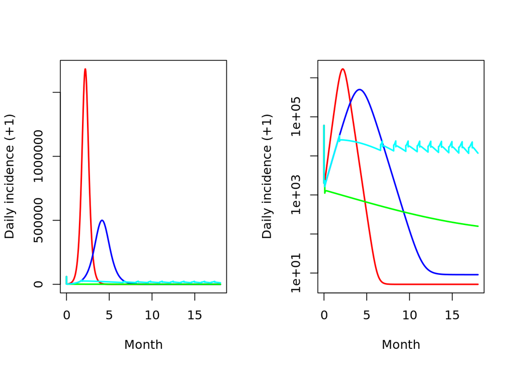

```r
par(mfrow=c(1,2))
for (s in c("","y")) {
    plot(y1$t/30,rowSums(y1$inf[,,1]/dt+1),
         log=s,col="red",type="l",lwd=2,xlim=c(0,18),
         xlab="Month",ylab="Daily incidence (+1)")
    points(y2$t/30,rowSums(y2$inf[,,1]/dt+1),col="blue",type="l",lwd=2)
    points(y3$t/30,rowSums(y3$inf[,,1]/dt+1),col="green",type="l",lwd=2)
    points(y4$t/30,rowSums(y4$inf[,,1]/dt+1),col="cyan",type="l",lwd=2)
}
```

Plot the sensitvities

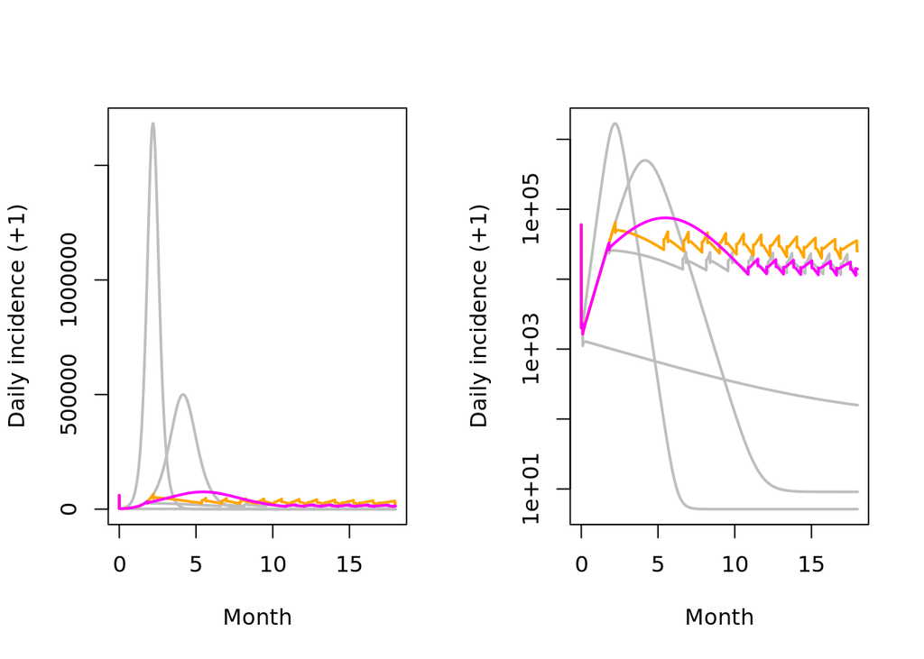

```r
par(mfrow=c(1,2))
for (s in c("","y")) {
    plot(y1$t/30,rowSums(y1$inf[,,1]/dt+1),
         log=s,col="gray",type="l",lwd=2,xlim=c(0,18),
         xlab="Month",ylab="Daily incidence (+1)")
    points(y2$t/30,rowSums(y2$inf[,,1]/dt+1),col="gray",type="l",lwd=2)
    points(y3$t/30,rowSums(y3$inf[,,1]/dt+1),col="gray",type="l",lwd=2)
    points(y4$t/30,rowSums(y4$inf[,,1]/dt+1),col="gray",type="l",lwd=2)
    points(y4A$t/30,rowSums(y4A$inf[,,1]/dt+1),col="orange",type="l",lwd=2)
    points(y4B$t/30,rowSums(y4B$inf[,,1]/dt+1),col="magenta",type="l",lwd=2)
}
```

Define a function to then output the total amount of infection

```r
tabdisp <- function(x)(formatC(signif(x,3), format="f", big.mark=",", digits=0))
tabdisp(sum(y1$inf[,,1]))
```

```
## [1] "53,200,000"
```

```r
tabdisp(sum(y2$inf[,,1]))
```

```
## [1] "34,900,000"
```

```r
tabdisp(sum(y3$inf[,,1]))
```

```
## [1] "274,000"
```

```r
tabdisp(sum(y4$inf[,,1]))
```

```
## [1] "9,170,000"
```

```r
tabdisp(sum(y4A$inf[,,1]))
```

```
## [1] "16,700,000"
```

```r
tabdisp(sum(y4B$inf[,,1]))
```

```
## [1] "16,900,000"
```

Output the total number of deaths

```r
tabdisp(y1$sevIn*0.2 + y1$sevOut)
```

```
## [1] "2,650,000"
```

```r
tabdisp(y2$sevIn*0.2 + y2$sevOut)
```

```
## [1] "1,740,000"
```

```r
tabdisp(y3$sevIn*0.2 + y3$sevOut)
```

```
## [1] "2,670"
```

```r
tabdisp(y4$sevIn*0.2 + y4$sevOut)
```

```
## [1] "446,000"
```

```r
tabdisp(y4A$sevIn*0.2 + y4A$sevOut)
```

```
## [1] "807,000"
```

```r
tabdisp(y4B$sevIn*0.2 + y4B$sevOut)
```

```
## [1] "834,000"
```

Plot cumulative deaths for different scenarios Plot

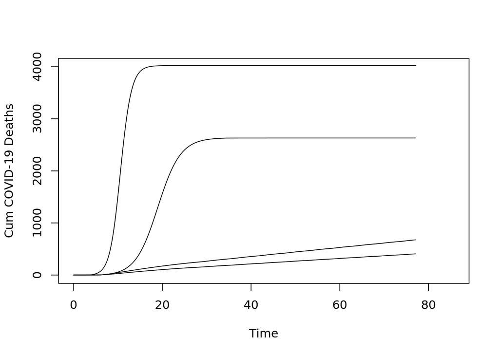

```r
par(mfrow=c(1,1))
plot(0:1,type="n",ylim=c(0,4000),xlim=c(0,600/7),
     ylab="Cum COVID-19 Deaths",xlab="Time")
y_scen1 <- (rowSums(0.2*y1$csevtreat[,,1])+rowSums(y1$csevuntreat[,,1]))/sum(pop)*100000
points(y1$t/7,y_scen1,type="l")
y_scen2 <- (rowSums(0.2*y2$csevtreat[,,1])+rowSums(y2$csevuntreat[,,1]))/sum(pop)*100000
points(y2$t/7,y_scen2,type="l")
y_scen4 <- (rowSums(0.2*y4$csevtreat[,,1])+rowSums(y4$csevuntreat[,,1]))/sum(pop)*100000
points(y4$t/7,y_scen4,type="l")
y_scen4a <- (rowSums(0.2*y4$csevtreat[,,1])+0.6*rowSums(y4$csevuntreat[,,1]))/sum(pop)*100000
points(y4$t/7,y_scen4a,type="l")
```

Output the proportion of herd immunity acheived at 18 months

```r
round(sum(y1$inf[,,1])/(sum(pop)/2)*100)
```

```
## [1] 161
```

```r
round(sum(y2$inf[,,1])/(sum(pop)/2)*100)
```

```
## [1] 106
```

```r
round(sum(y3$inf[,,1])/(sum(pop)/2)*100)
```

```
## [1] 1
```

```r
round(sum(y4$inf[,,1])/(sum(pop)/2)*100)
```

```
## [1] 28
```

```r
round(sum(y4A$inf[,,1])/(sum(pop)/2)*100)
```

```
## [1] 51
```

```r
round(sum(y4B$inf[,,1])/(sum(pop)/2)*100)
```

```
## [1] 51
```

Include some model calibration runs as evidence of correctness because there is a little bit of model here and its import that the NGM calc is correct Work to load up excess mortality data. This will go futehr up in the final version of thius

```r
localfn <- "/mnt/c/Users/sr/Documents/tmpdata/excess_death.csv"
localfn_w <- "/mnt/c/Users/sr/Documents/tmpdata/excess_death_econ.csv"
## webfn <- "https://raw.githubusercontent.com/owid/covid-19-data/4132d2c726fa406d5ff934b4f6411f463992a07d/public/data/excess_mortality/excess_mortality.csv"
## x <- read.csv(webfn)
## write.csv(x,file=localfn,row.names = FALSE)
## wwebfn <- "https://raw.githubusercontent.com/owid/covid-19-data/master/public/data/excess_mortality/excess_mortality_economist_estimates.csv"
## w <- read.csv(wwebfn)
## write.csv(w,file=localfn_w,row.names=FALSE)
```

These bits need to be coded as a data object

```r
y <- read.csv(localfn)
z <- read.csv(localfn_w)
names(z)
```

```
##  [1] "country"
##  [2] "cumulative_estimated_daily_excess_deaths"
##  [3] "cumulative_estimated_daily_excess_deaths_ci_95_top"
##  [4] "cumulative_estimated_daily_excess_deaths_ci_95_bot"
##  [5] "cumulative_estimated_daily_excess_deaths_per_100k"
##  [6] "cumulative_estimated_daily_excess_deaths_ci_95_top_per_100k"
##  [7] "cumulative_estimated_daily_excess_deaths_ci_95_bot_per_100k"
##  [8] "estimated_daily_excess_deaths"
##  [9] "estimated_daily_excess_deaths_ci_95_top"
## [10] "estimated_daily_excess_deaths_ci_95_bot"
## [11] "estimated_daily_excess_deaths_per_100k"
## [12] "estimated_daily_excess_deaths_ci_95_top_per_100k"
## [13] "estimated_daily_excess_deaths_ci_95_bot_per_100k"
## [14] "date"
```

```r
dim(z)
```

```
## [1] 48110    14
```

```r
length(table(z$country))
```

```
## [1] 237
```

```r
## all(dim(x) == dim(y))
## all(names(x) == names(y))
df <- y %>%
  dplyr::filter(time_unit=="weekly", date < as.Date("2021-08-31")) %>%
  dplyr::select("location", "cum_excess_per_million_proj_all_ages","date") %>%
  dplyr::rename("cumexcess" = "cum_excess_per_million_proj_all_ages",
                "country"="location") %>%
  tidyr::spread(country,cumexcess)
dim(df)
```

```
## [1] 87 56
```

```r
names(df)
```

```
##  [1] "date"             "Australia"        "Austria"          "Belgium"
##  [5] "Bulgaria"         "Canada"           "Chile"            "Colombia"
##  [9] "Croatia"          "Cyprus"           "Czechia"          "Denmark"
## [13] "Ecuador"          "England & Wales"  "Estonia"          "Finland"
## [17] "France"           "French Guiana"    "Germany"          "Greece"
## [21] "Guadeloupe"       "Guatemala"        "Hungary"          "Iceland"
## [25] "Iran"             "Ireland"          "Israel"           "Italy"
## [29] "Latvia"           "Lithuania"        "Luxembourg"       "Malta"
## [33] "Martinique"       "Mayotte"          "Mexico"           "Montenegro"
## [37] "Netherlands"      "New Zealand"      "Northern Ireland" "Norway"
## [41] "Peru"             "Poland"           "Portugal"         "Puerto Rico"
## [45] "Reunion"          "Romania"          "Scotland"         "Slovakia"
## [49] "Slovenia"         "South Africa"     "South Korea"      "Spain"
## [53] "Sweden"           "Switzerland"      "United Kingdom"   "United States"
```

```r
df2 <- z %>%
  dplyr::filter(date < as.Date("2021-08-31")) %>%
  dplyr::select("date","country",
               "cumulative_estimated_daily_excess_deaths_per_100k") %>%
  dplyr::rename("cumexcess" =
                  "cumulative_estimated_daily_excess_deaths_per_100k") %>%
  tidyr::spread(country,cumexcess)

dim(df2)
```

```
## [1]  88 238
```

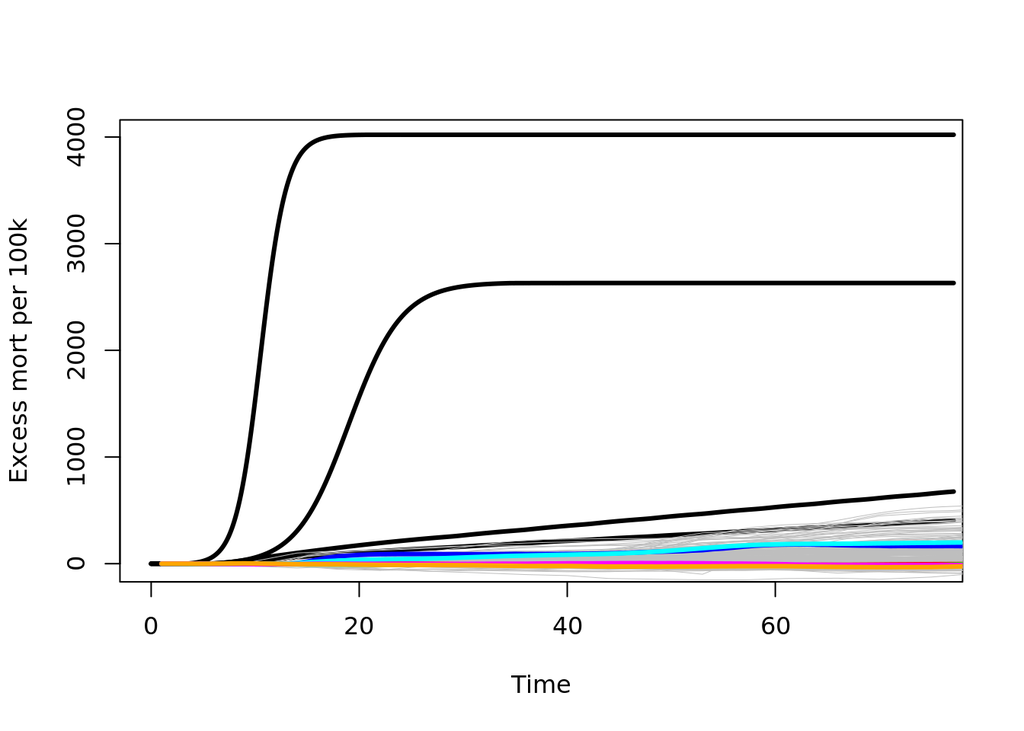

```r
colnames <- names(df2)
windex <- which(colnames=="World")
dindex <- which(colnames=="date")
countries <- colnames[-c(windex,dindex)]
ncountries <- length(countries)

plot_cum <- function(ymax=4000) {
  plot(0:1,type="n",ylim=c(-10,ymax),xlim=c(0,75),
       ylab="Excess mort per 100k",xlab="Time")
  points(y1$t/7,y_scen1,type="l",col="black",lwd=3)
  points(y2$t/7,y_scen2,type="l",col="black",lwd=3)
  points(y4$t/7,y_scen4,type="l",col="black",lwd=3)
  points(y4$t/7,y_scen4a,type="l",col="black",lwd=3)
  for (c in countries) {
    points(df2[,c],type="l",col="grey",lwd=0.5)
  }
  points(df2$`United Kingdom`,type="l",col="blue",lwd=3)
  points(df2$Australia,type="l",col="red",lwd=3)
  points(df2$China,type="l",col="green",lwd=3)
  points(df2$`United States`,type="l",col="cyan",lwd=3)
  points(df2$Norway,type="l",col="magenta",lwd=3)
  points(df2$Taiwan,type="l",col="orange",lwd=3)
}
plot_cum(4000)
```

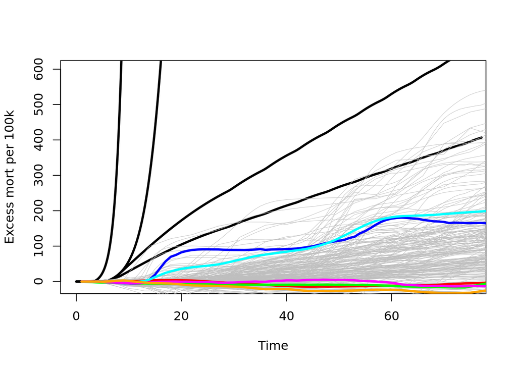

```r
plot_cum(600)
```